# SEQUENCE FORCASTING USING LSTM (RNN)

The experiment below is to exhibit the capability of LSTM Network implemented using Keras in forecasting the next number of thegiven input number series. We shall develop a single leayer LSTM Network first and then try building a 2 layer Network. This will help us compare the multi layer network perfromance.

```python
from keras.models import Sequential
from keras.layers import Dense
from keras.layers import LSTM
from sklearn.model_selection import train_test_split
import numpy as np
import matplotlib.pyplot as plt
```

### Data Preparation

For the experiment let us generate the data as below:

1. Input Data : As sequence of 5 numbers as 1x1 vectors - eg : [[2],[3],[4],[5],[6]]
2. Target Data : A single numeric element which is teh next one in sequence with the input data. eg: [7]

```python
Data = [[[i+j] for i in range(5)] for j in range(100)]
target = [(i+5) for i in range(100)]
```

```python
print('Data (Each element is a Vector of size 1x1 and every input sequence has 5 such vectors in it) :')
for i in range(5):
    print(Data[i])
print('target (Output is just a number element) :')
for i in range(5):
    print(target[i])
```

```
Data (Each element is a Vector of size 1x1 and every input sequence has 5 such vectors in it) :
[[0], [1], [2], [3], [4]]
[[1], [2], [3], [4], [5]]
[[2], [3], [4], [5], [6]]
[[3], [4], [5], [6], [7]]
[[4], [5], [6], [7], [8]]
target (Output is just a number element) :
5
6
7
8
9
```

```python
data = np.array(Data,dtype=float)
target = np.array(target,dtype=float)
# The shape details below will be used as parameters to configure the LSTM network
print(data.shape)
print(target.shape)
```

```
(100, 5, 1)
(100,)
```

### Train Test Data Preparation

```python
X_train,X_test,y_train,y_test = train_test_split(data,target,test_size=0.2,random_state=4)
```

### Model Building - LSTM RNN Configuration

```python
model=Sequential()
model.add(LSTM((1),batch_input_shape=(None,5,1),return_sequences=False))
```

```python
model.compile(loss='mean_absolute_error',optimizer='adam',metrics=['accuracy'])
```

```python
history = model.fit(X_train,y_train,epochs=50,validation_data=(X_test,y_test))
```

```
Train on 80 samples, validate on 20 samples
```

```python
results= model.predict(X_test)
```

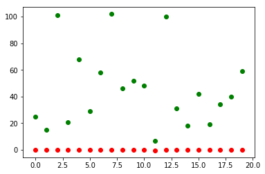

```python
plt.scatter(range(20),results,c='r')
plt.scatter(range(20),y_test,c='g')
plt.show()
```

### Inference :

The Model is unable to learn anything from the data. The probable next steps can be increasing epochs and normalising the data input. Let us try Normalising the input data. Without Normalising the gradient becomes very high and difficult for the model to learn.

### Iteration 2 with Normalised Data Features

```python
Data = [[[(i+j)/100] for i in range(5)] for j in range(100)]
target = [((i+5)/100) for i in range(100)]
data = np.array(Data,dtype=float)
target = np.array(target,dtype=float)
X_train,X_test,y_train,y_test = train_test_split(data,target,test_size=0.2,random_state=4)
```

```python
model=Sequential()
model.add(LSTM((1),batch_input_shape=(None,5,1),return_sequences=False))
model.compile(loss='mean_absolute_error',optimizer='adam',metrics=['accuracy'])
history = model.fit(X_train,y_train,epochs=1000,validation_data=(X_test,y_test))
```

```
Train on 80 samples, validate on 20 samples
```

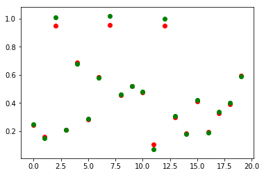

```python
results= model.predict(X_test)
plt.scatter(range(20),results,c='r')
plt.scatter(range(20),y_test,c='g')
plt.show()
```

### Inference :

Now The Predictions from the Model seems to have improved a lot better and teh accuracy seems to be very high and good. We have also increased the epochs to let the loss settle to a stable level.

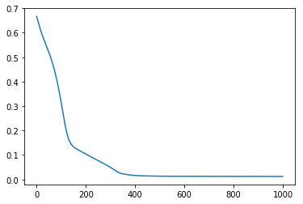

```python
plt.plot(history.history['loss'])
plt.show()
```

### Iteration 3: Multilayer LSTM Network

Let us Try to add another layer to the Network and see if the results improve. This time the output from the network will be a sequence which will be passed to the next layer. Adding layers will also impact the loss pattern.

```python
model=Sequential()
model.add(LSTM((1),batch_input_shape=(None,5,1),return_sequences=True))
model.add(LSTM((1),return_sequences=False))
model.compile(loss='mean_absolute_error',optimizer='adam',metrics=['accuracy'])
history = model.fit(X_train,y_train,epochs=1000,validation_data=(X_test,y_test))
```

```
Train on 80 samples, validate on 20 samples
```

```
C:\Users\Optimus Prime\Anaconda3\lib\site-packages\keras\callbacks.py:122: UserWarning: Method on_batch_end() is slow compared to the batch update (0.119007). Check your callbacks.
  % delta_t_median)
```

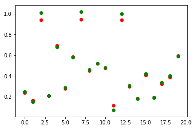

```python
results= model.predict(X_test)
plt.scatter(range(20),results,c='r')
plt.scatter(range(20),y_test,c='g')
plt.show()
```

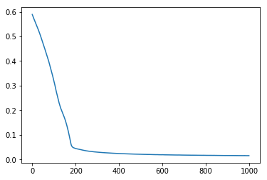

```python
plt.plot(history.history['loss'])
plt.show()
```